# Statistik fuer Biologie FS 2026

# Solutions

[Back to main page.](https://s-peischl.github.io/StatForBioFS22) [Back to exercises.](https://s-peischl.github.io/StatForBioFS22/Exercises_web.html)

# Week 1

## Exercise 1

1. No. Collectors did not choose randomly, but preferred rarer types over more common ones.
2. It is a sample of convenience.
3. There is bias in every year’s sample because rare types are over-represerented. Further this bias might change across years as the frequencies of the two morphs have changed over time.

## Exercise 2

1. Discrete.
2. Technically it is a discrete variable (because fractions can be enumerated / are restricted to finitely many values in a finite sample) but it makes sense to treat it as a continuous variable if the sample is very large.
3. Discrete. There are no half crimes.
4. Continuous. Body mass is continuous and hence the log as well.

## Exercise 3

1. E(xplanatory): Altitude (categorical: high vs low) R(esponse): Growth rate S(tudy type): Observational
2. E: Treatment (standard vs. tasploglutide) R: Rate of insulin release S: Experimental
3. E: Health status (schizophrenia vs. healthy) R: Frequency of illegal drug use S: Observational
4. E:Number of legs R: Survival propability S: Experimental
5. E: Treatment (advanced communication therapy vs. social visits without formal therapy) R: Communication ability S: Experimental

## Exercise 4

The main problem is a strong bias in the sample. To see this, consider the sample of planes that were used in this study. Only planes that were *not* hit in critical areas were available to estimate the distribution of bullet holes. Planes that were hit in a critical area, i.e., one that leads to a crash, were not available because they did not return to base. With this knowledge, it becomes clear that it would have been better to reinforce the areas were no, or very little, bullet holes were found, namely the cockpit and engine.

## Exercise 5

1. The population parameter being estimated is all the small mammals of Kruger National Park.
2. No, the sample is not likely to be random. In a random sample, every individual has the same chance of being selected. But some small mammals might be easier to trap than others (for example, trapping only at night might miss all the mammals active only in the day time). In a random sample individuals are selected independently. Multiple animals caught in the same trap might not be independent if they are related or live near one another (this is harder to judge).
3. The number of species in the sample might underestimate the number in the Park if sampling was not random (e.g., if daytime mammals were missed), or if rare species happened to avoid capture. Even if the sample is perfectly random, the estimator will underestimated the true number in most cases. You can sample fewer species just by chance, but not more species as there actually are. Thus - on average - you will underestimate the true number.

# Week 2

## Exercise 6

1. You should see a blank plot. This is what ggplot does, it simply creates a “canvas” to which you can add “layers”.
2. How many rows are in mpg? How many columns?

```r
str(mpg)
```

```
## tibble [234 × 11] (S3: tbl_df/tbl/data.frame)
##  $ manufacturer: chr [1:234] "audi" "audi" "audi" "audi" ...
##  $ model       : chr [1:234] "a4" "a4" "a4" "a4" ...
##  $ displ       : num [1:234] 1.8 1.8 2 2 2.8 2.8 3.1 1.8 1.8 2 ...
##  $ year        : int [1:234] 1999 1999 2008 2008 1999 1999 2008 1999 1999 2008 ...
##  $ cyl         : int [1:234] 4 4 4 4 6 6 6 4 4 4 ...
##  $ trans       : chr [1:234] "auto(l5)" "manual(m5)" "manual(m6)" "auto(av)" ...
##  $ drv         : chr [1:234] "f" "f" "f" "f" ...
##  $ cty         : int [1:234] 18 21 20 21 16 18 18 18 16 20 ...
##  $ hwy         : int [1:234] 29 29 31 30 26 26 27 26 25 28 ...
##  $ fl          : chr [1:234] "p" "p" "p" "p" ...
##  $ class       : chr [1:234] "compact" "compact" "compact" "compact" ...
```

There are 234 observations of 11 variables. thus, there are 11 columns and 234 rows. we can confirm this by looking at the dimension of the underlying data matrix:

```r
dim(mpg)
```

```
## [1] 234  11
```

```r
?mpg
```

drv is a categorical vaiable indicating the drive type: f = front-wheel drive, r = rear wheel drive, 4 = 4wd

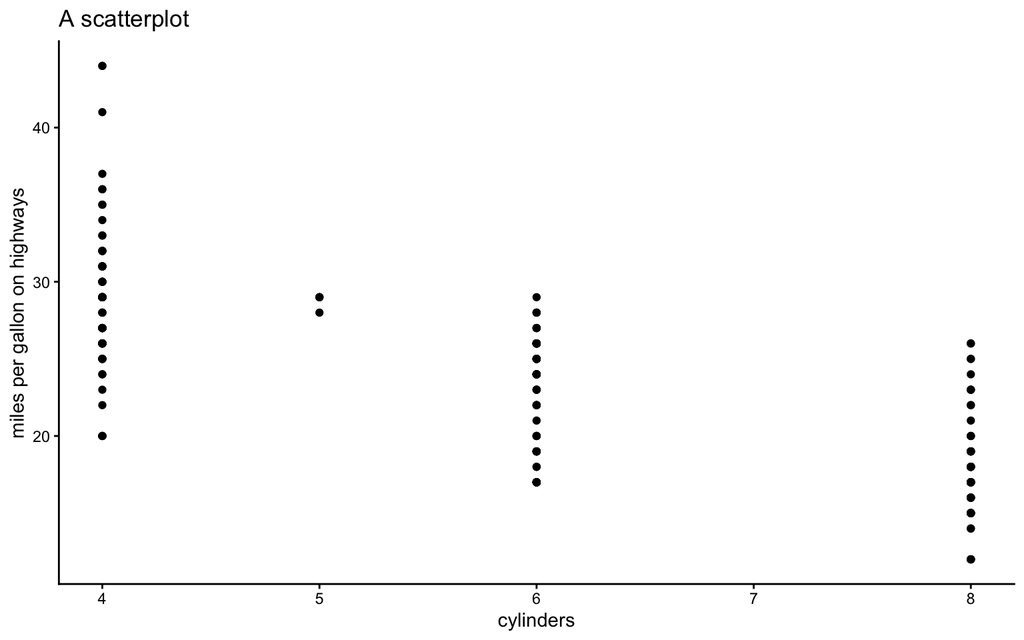

```r
ggplot(data  = mpg) +
  geom_point(mapping = aes(y = hwy,x = cyl)) +
  theme_classic() +
  labs(title = "A scatterplot", y = "miles per gallon on highways",x="cylinders")
```

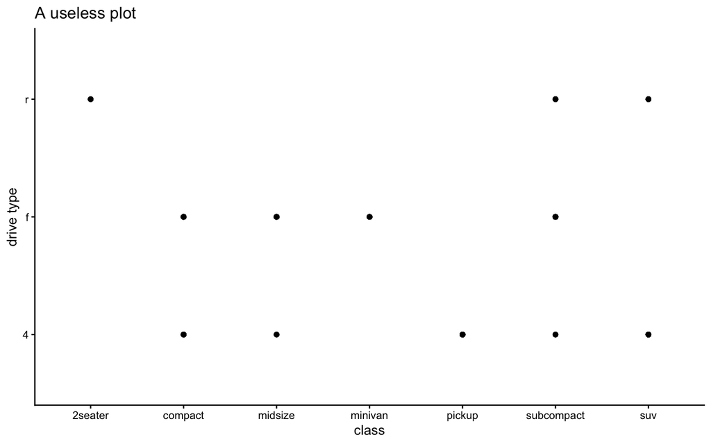

```r
ggplot(data  = mpg) +
  geom_point(mapping = aes(x = class,y = drv)) +
  theme_classic() +
  labs(title = "A useless plot", x = "class",y="drive type")
```

both drv and class are categorical variable and it does not make sense to visualize them this way. What would be a better way to show these data?

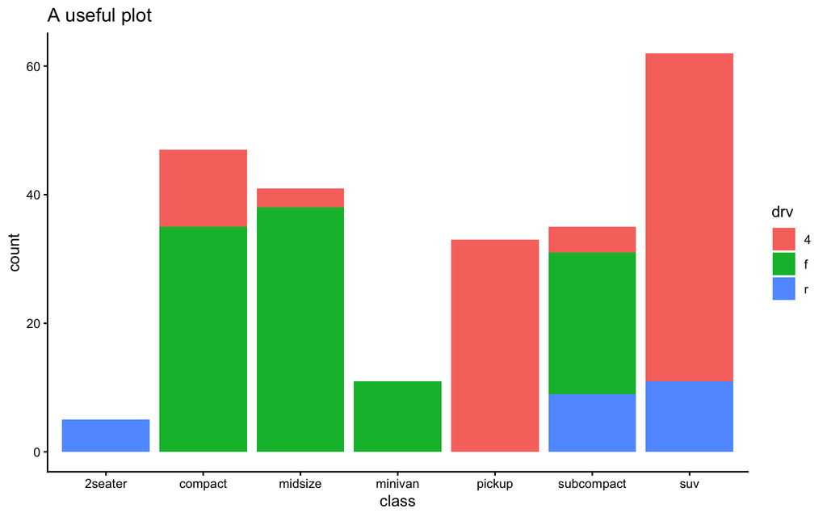

```r
ggplot(data  = mpg) +
  geom_bar(mapping = aes(x = class,fill = drv)) +
  theme_classic() +
  labs(title = "A useful plot", x = "class",y="count")
```

and here is a pretty example:

```r
library(viridis)
```

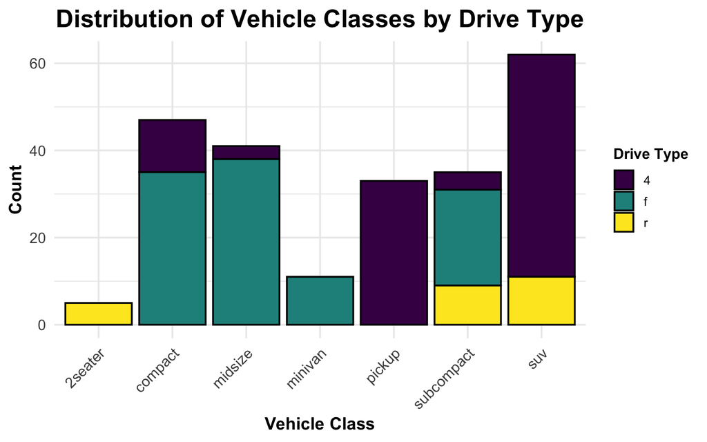

```r
ggplot(data = mpg) +
  geom_bar(mapping = aes(x = class, fill = drv), position = "stack", color = "black") +
  scale_fill_viridis(discrete = TRUE) +
  theme_minimal(base_size = 15) +
  theme(
    plot.title = element_text(hjust = 0.5, size = 20, face = "bold"),
    axis.title.x = element_text(size = 14, face = "bold"),
    axis.title.y = element_text(size = 14, face = "bold"),
    axis.text.x = element_text(angle = 45, hjust = 1),
    legend.title = element_text(size = 12, face = "bold"),
    legend.text = element_text(size = 10)
  ) +
  labs(
    title = "Distribution of Vehicle Classes by Drive Type",
    x = "Vehicle Class",
    y = "Count",
    fill = "Drive Type"
  )
```

6. Color is used wihtin the aesthetics function, where we specifiy which varibales should be used. “blue” is however not a variable in our data frame. Thus it is ignored. The follwoing code creates the correct plot:

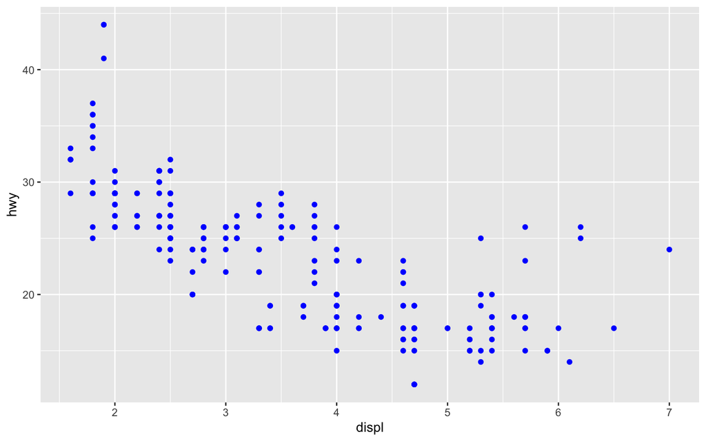

```r
ggplot(data = mpg) +
  geom_point(mapping = aes(x = displ, y = hwy), color = "blue")
```

7. A continuous variable will lead ot a continuous color gradient rather than a discrete set of colors.

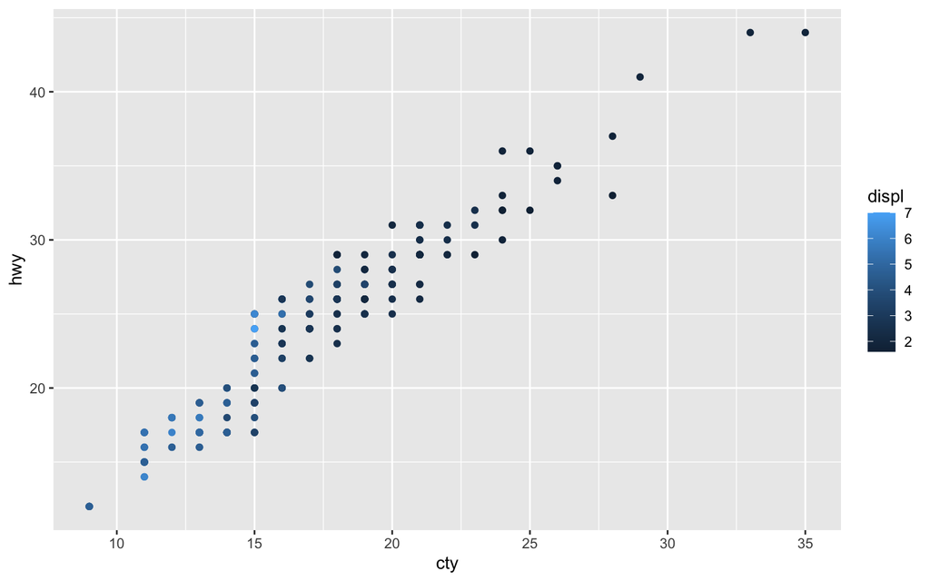

```r
ggplot(data = mpg) +
  geom_point(mapping = aes(x = cty, y = hwy, color = displ))
```

8. The “+” symbol always has to be in the top row:

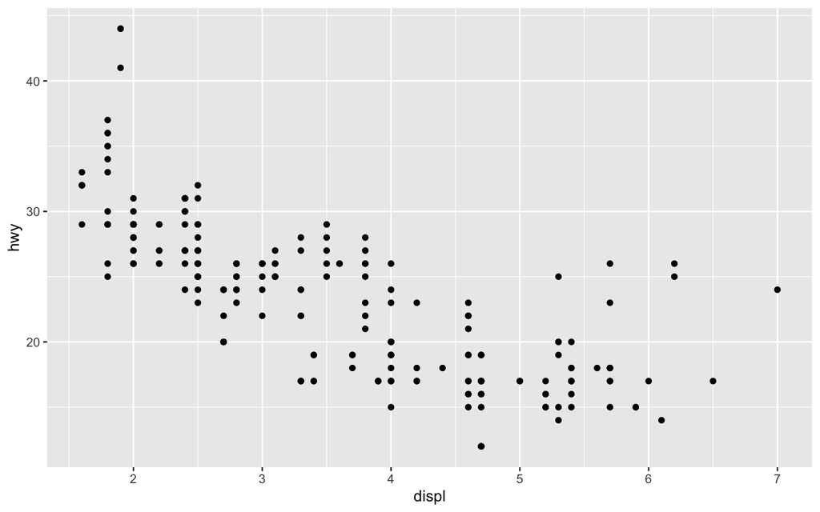

```r
ggplot(data = mpg) +
  geom_point(mapping = aes(x = displ, y = hwy))
```

# Week 3

## Exercise 7

```r
genes <- read.csv(url("http://www.zoology.ubc.ca/~schluter/WhitlockSchluter/wp-content/data/chapter04/chap04e1HumanGeneLengths.csv"))

# a)

n = dim(genes)[1]
print(n)
```

```
## [1] 20290
```

```r
# b)
sum.gene.lengths = sum(genes$geneLength)

# c)

mean.gene.length1 = sum.gene.lengths/n
mean.gene.length2 = mean(genes$geneLength)

print(mean.gene.length1)
```

```
## [1] 2622.027
```

```r
print(mean.gene.length2)
```

```
## [1] 2622.027
```

```r
# d)
square.sum.gene.lengths = sum(genes$geneLength^2)
print(square.sum.gene.lengths)
```

```
## [1] 223678143206
```

```r
# e)

# by hand:
variance.gene.length = sum((genes$geneLength - mean.gene.length1)^2)/(n-1)

print(variance.gene.length)
```

```
## [1] 4149235
```

```r
# for comparison:
var(genes$geneLength)
```

```
## [1] 4149235
```

```r
# f)
sd(genes$geneLength)
```

```
## [1] 2036.967
```

```r
# or

sd.gene.length = sqrt(variance.gene.length)

# g)

cv.gene.length = sd.gene.length/mean.gene.length1
print(cv.gene.length)
```

```
## [1] 0.7768672
```

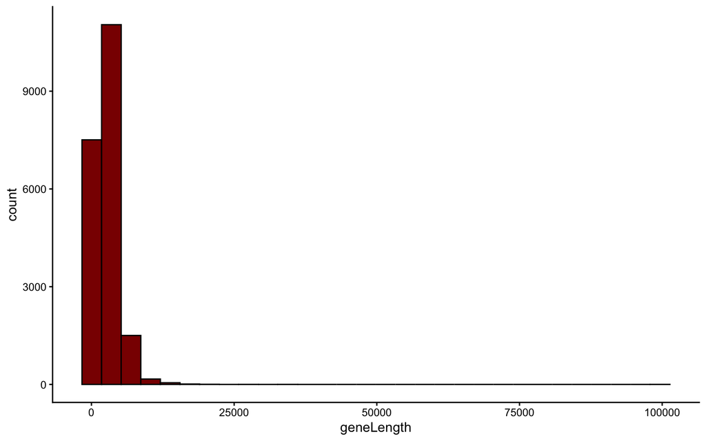

```r
# h)
# Which one do you like best?

ggplot(data = genes) +
  geom_histogram(mapping = aes(x = geneLength),color="black",fill="darkred") +
  theme_classic()
```

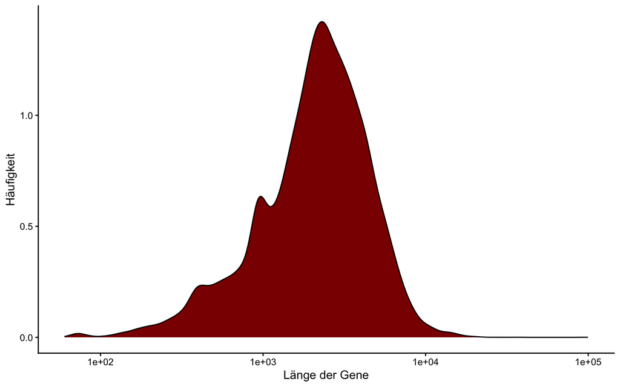

```r
ggplot(data = genes) +
  geom_density(mapping = aes(x = geneLength),color="black",fill="darkred") +
  xlab("Länge der Gene") +
  ylab("Häufigkeit") +
  scale_x_log10() +
  theme_classic()
```

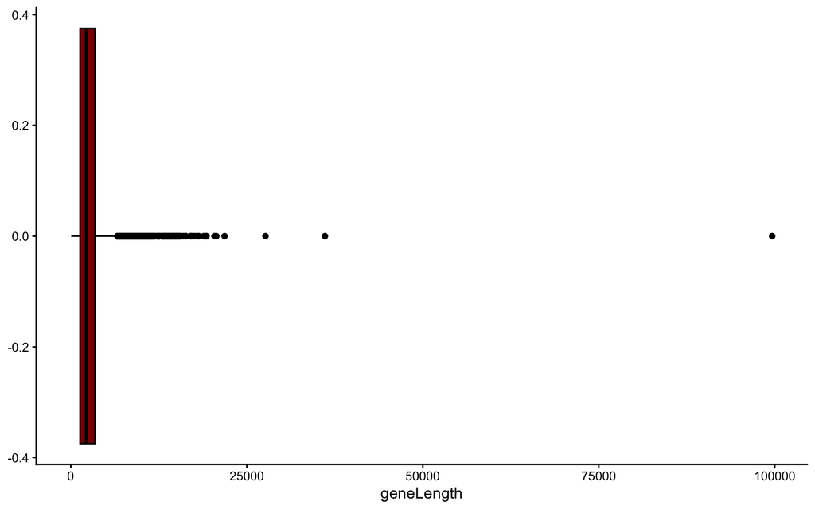

```r
ggplot(data = genes) +
  geom_boxplot(mapping = aes(y = geneLength),color="black",fill="darkred") +
  theme_classic() +
  coord_flip()
```

# Week 4

## Exercise 8

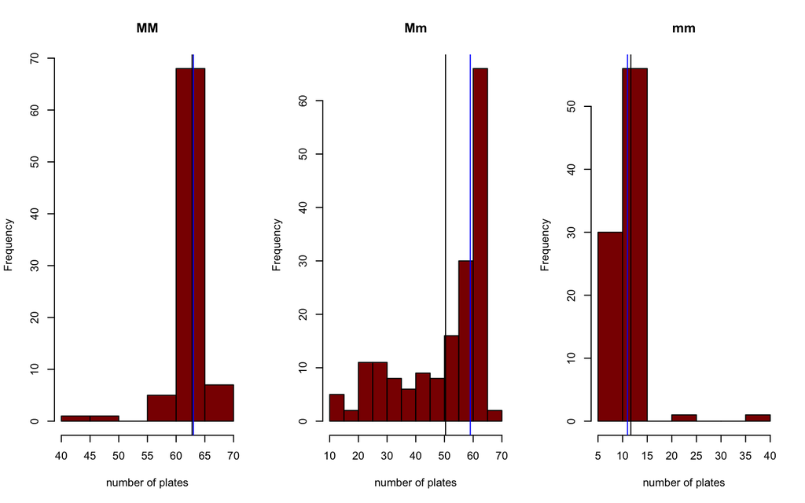

```r
# load the data file:
stickleback <- read.csv(url("http://www.zoology.ubc.ca/~schluter/WhitlockSchluter/wp-content/data/chapter03/chap03e3SticklebackPlates.csv"))

# one possible solution:

mean.mm = mean(stickleback$plates[stickleback$genotype=="mm"])
mean.mM = mean(stickleback$plates[stickleback$genotype=="Mm"])
mean.MM = mean(stickleback$plates[stickleback$genotype=="MM"])

median.mm = median(stickleback$plates[stickleback$genotype=="mm"])
median.mM = median(stickleback$plates[stickleback$genotype=="Mm"])
median.MM = median(stickleback$plates[stickleback$genotype=="MM"])

par(mfrow = c(1,3))

hist(stickleback$plates[stickleback$genotype=="MM"],
     main = "MM",xlab = "number of plates",
     col="darkred")

abline(v = mean.MM,col="black")
abline(v = median.MM,col="blue")

hist(stickleback$plates[stickleback$genotype=="Mm"],
     main = "Mm",xlab = "number of plates",
     col="darkred")
abline(v = mean.mM,col="black")
abline(v = median.mM,col="blue")

hist(stickleback$plates[stickleback$genotype=="mm"],
     main = "mm",xlab = "number of plates",
     col="darkred")
abline(v = mean.mm,col="black")
abline(v = median.mm,col="blue")
```

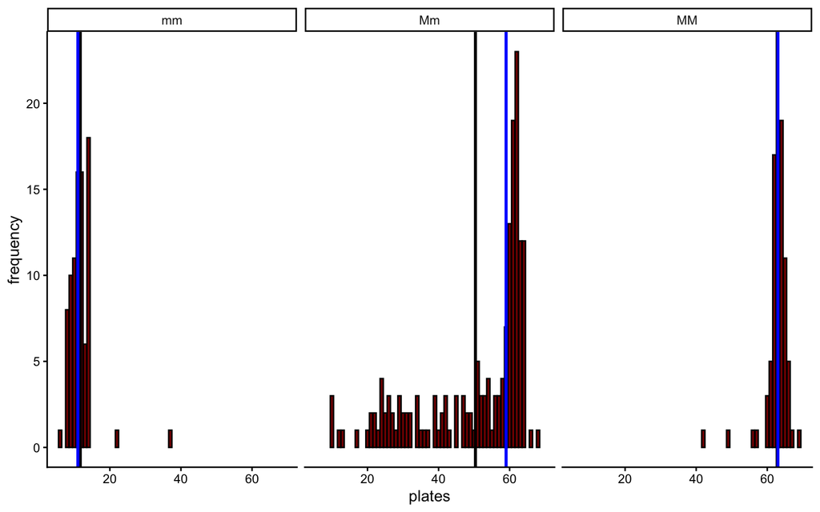

```r
# alternatively, we can first create a data frame
# with the means per genotype
# check out the help function of ddply
# (this is only one way to do this, you can also do it by
# "hand" or using other functions such as tapply) :

library(dplyr)
df.mean = ddply(stickleback, "genotype", summarize, m.number = mean(plates))
df.median = ddply(stickleback, "genotype", summarize, m.number = median(plates))

# then we plot it with a single ggplot
ggplot() +
  geom_bar(data = stickleback, mapping = aes(x=plates),binwidth=5,color="black",fill="darkred") +
  geom_vline(data = df.mean, aes(xintercept=m.number),col="black",size=1) +
  geom_vline(data = df.median, aes(xintercept=m.number),col="blue",size = 1) +
  facet_wrap(~ genotype) +
  ylab("frequency") +
  theme_classic()
```

## Exercise 9

The code simualtes the samplind distirbution of the mean. Here is an alternative version for the Poisson distribution:

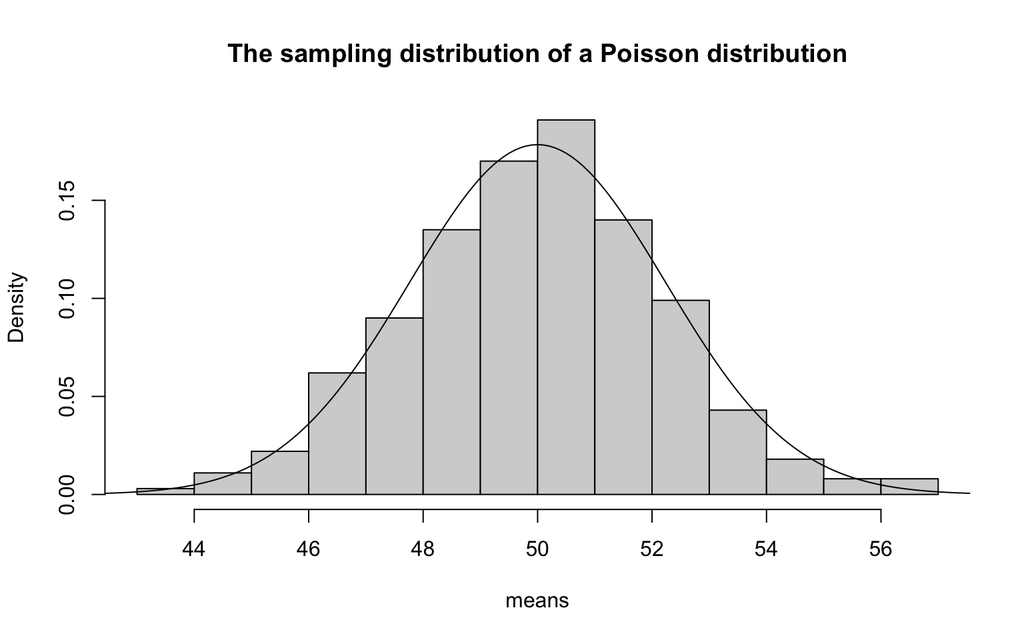

```r
# We choose the Poisson distribution with mean lambda = 50
lambda = 50

# We do 1000 replicates
reps = 1000

# We choose the sample size n to be 10
sample_size = 10

# the means of each sample will be stroed in this vector
means = vector("numeric",reps)

# in this loop, we will calcualte the means of the sample
for (i in 1:reps)
{
  # take a sample of the poisson distribution
  sample = rpois(sample_size,lambda)

  # store the mean in our vector
  means[i] = mean(sample)
}

# a histogram - note that we set freq = FALSE to
# show realtive frequencies
hist(means,freq=F,main="The sampling distribution of a Poisson distribution")

# we specify the x values for the theoretical poisson
x = seq(0,3*lambda,by=0.1)

#we calcualte the standard error:
SE = sqrt(lambda)/sqrt(sample_size)

# caclualte the corresponding PDF of the poisson
y = dnorm(x,lambda,SE)

lines(x,y)
```

# Week 5

## Exercise 10

1. What is the probability that a randomly drawn slice has pepperoni on it?

$$P(\text{pepperoni}) = \frac{5}{8} =
0.625 = 62.5\%$$

2. What is the probability that a randomly drawn slice has both pepperoni and anchovies on it?

$$P(\text{pepperoni and anchovies}) =
\frac{2}{8} = 0.25 = 25\%$$

3. What is the probability that a randomly drawn slice has either pepperoni or anchovies on it?

$$P(\text{pepperoni or anchovies}) =
\frac{7}{8} = 0.875 = 87.5\%$$

4. Are pepperoni and anchovies mutually exclusive on this pizza?

No. Two slices contain both pepperoni and anchovies, so the events are not mutually exclusive.

5. Are olives and mushrooms mutually exclusive on this pizza?

Yes. No slice contains both olives and mushrooms.

6. Are getting mushrooms and getting anchovies independent when randomly picking a slice of pizza?

No, because

$$P(\text{anchovy}) = \frac{4}{8} =
0.5$$

$$P(\text{mushroom}) = \frac{3}{8} =
0.375$$

$$P(\text{mushroom and anchovy}) =
\frac{1}{8} = 0.125$$

If the events were independent, we would have

$$P(\text{mushroom})P(\text{anchovy}) =
\frac{3}{8} \times \frac{4}{8} = \frac{3}{16} = 0.1875$$

Since $0.125 \ne 0.1875$, the events are not independent.

7. If I pick a slice from this pizza and tell you that it has olives on it, what is the chance that it also has anchovies?

$$P(\text{anchovy} \mid \text{olive}) =
\frac{P(\text{anchovy and olive})}{P(\text{olive})}$$

$$= \frac{1/8}{2/8} = \frac{1}{2} = 0.5 =
50\%$$

8. If I pick a slice from this pizza and tell you that it has anchovies on it, what is the chance that it also has olives?

$$P(\text{olive} \mid \text{anchovy}) =
\frac{P(\text{olive and anchovy})}{P(\text{anchovy})}$$

$$= \frac{1/8}{4/8} = \frac{1}{4} = 0.25 =
25\%$$

1. Seven of your friends each choose a slice at random and eat them without telling you what toppings they had. What is the chance that the last slice has olives on it?

$$P(\text{last slice has olives}) =
\frac{2}{8} = 0.25 = 25\%$$

Each slice is equally likely to be the last slice.

10. You choose two slices at random. What is the chance that they both have olives?

$$P(\text{first slice has olives}) =
\frac{2}{8}$$

$$P(\text{second slice has olives}) =
\frac{1}{7}$$

$$P(\text{both slices have olives}) =
\frac{2}{8} \times \frac{1}{7} = \frac{1}{28} \approx 3.6\%$$

11. What is the probability that a randomly chosen slice does not have pepperoni on it?

$$P(\text{no pepperoni}) = 1 -
P(\text{pepperoni}) = \frac{3}{8} = 37.5\%$$

12. Draw a pizza for which mushrooms, olives, anchovies, and pepperoni are all mutually exclusive.

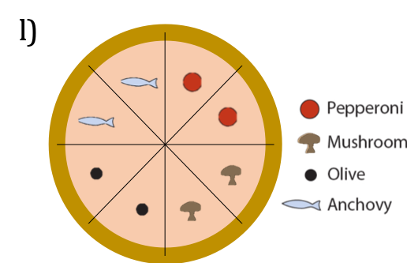

A pizza for which mushrooms, olives, anchovies and pepperoni are all mutually exclusive

## Exercise 11

1. What is the probability that you picked up no dangerous snakes?

$$P(\text{no dangerous snakes}) =
P(\text{no dangerous snake in left hand}) \times P(\text{no dangerous
snake in right hand})$$

$$= \frac{3}{8} \times \frac{2}{7} =
\frac{6}{56} = 0.107 \approx 10.7\%$$

2. Assume that any dangerous snake that you pick up has a probability of 0.8 of biting you. The defanged snakes do not bite. What is the chance that, in picking up your two snakes, you are bitten at least once?

$$P(\text{bite}) = P(\text{bite} \mid
0)P(0) + P(\text{bite} \mid 1)P(1) + P(\text{bite} \mid
2)P(2)$$

From (a) we know:

$$P(0 \text{ dangerous snakes}) =
0.107$$

Next we calculate:

$$P(1 \text{ dangerous snake}) =
\frac{5}{8} \times \frac{3}{7} + \frac{3}{8} \times \frac{5}{7} =
0.536$$

$$P(2 \text{ dangerous snakes}) =
\frac{5}{8} \times \frac{4}{7} = 0.357$$

$$P(\text{bite} \mid 0 \text{ dangerous
snakes}) = 0$$

$$P(\text{bite} \mid 1 \text{ dangerous
snake}) = 0.8$$

$$P(\text{bite} \mid 2 \text{ dangerous
snakes}) = 1 - (1-0.8)^2 = 0.96$$

Putting everything together:

$$P(\text{bite}) = (0 \times 0.107) + (0.8
\times 0.536) + (0.96 \times 0.357) = 0.772$$

3. If you picked up one snake and it didn’t bite you, what is the probability that it is defanged?

Using Bayes’ theorem:

$$P(\text{defanged} \mid \text{no bite}) =
\frac{P(\text{no bite} \mid
\text{defanged})P(\text{defanged})}{P(\text{no bite})}$$

$$P(\text{no bite} \mid \text{defanged}) =
1$$

$$P(\text{defanged}) =
\frac{3}{8}$$

Now calculate $P(\text{no bite})$:

$$P(\text{no bite}) =
P(\text{defanged})P(\text{no bite} \mid \text{defanged}) +
P(\text{dangerous})P(\text{no bite} \mid \text{dangerous})$$

$$= \frac{3}{8} \times 1 + \frac{5}{8}
\times (1-0.8) = 0.5$$

Therefore

$$P(\text{defanged} \mid \text{no bite}) =
\frac{1 \times (3/8)}{0.5} = 0.75 = 75\%$$

## Exercise 12

1. What is the probability that all five researchers have calculated an interval that includes the true value of the parameter?

$$0.95^5 = 0.774$$

2. What is the probability that at least one does not include the true parameter value?

$$1 - 0.95^5 = 0.226$$

# Week 6

## Exercise 13

We first calculate the mean for each genotype:

```r
stickleback = read.csv("~/Dropbox/Teaching/StatisticsForBiology/chap03e3SticklebackPlates.csv")

mean.mm = mean(stickleback$plates[stickleback$genotype=="mm"])
mean.Mm = mean(stickleback$plates[stickleback$genotype=="Mm"])
mean.MM = mean(stickleback$plates[stickleback$genotype=="MM"])
```

Next the upper and lower limit of the 95% CI using a t-test:

```r
t.t.mm = t.test(stickleback$plates[stickleback$genotype=="mm"])
t.t.Mm = t.test(stickleback$plates[stickleback$genotype=="Mm"])
t.t.MM = t.test(stickleback$plates[stickleback$genotype=="MM"])

CI.mm = t.t.mm$conf.int
CI.Mm = t.t.Mm$conf.int
CI.MM = t.t.MM$conf.int
```

We put it all in a dataframe:

```r
df = data.frame(means = c(mean.mm,mean.Mm,mean.MM),
                lower = c(CI.mm[1],CI.Mm[1],CI.MM[1]),
                upper = c(CI.mm[2],CI.Mm[2],CI.MM[2]),
                genotypes = c("mm","Mm","MM"))
```

Now we can plot everything:

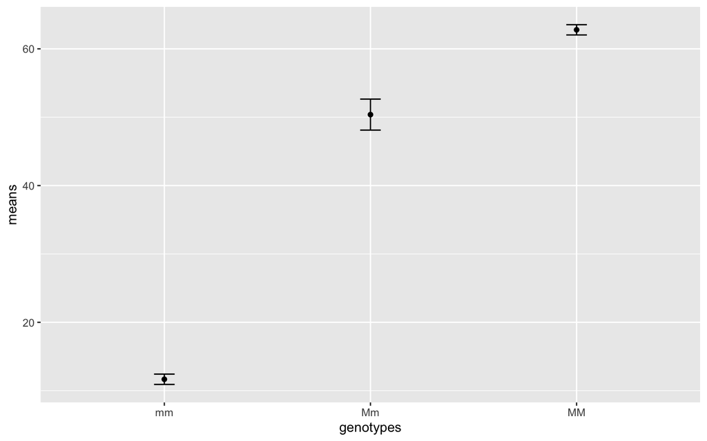

```r
ggplot(data = df) +
  geom_errorbar(mapping = aes(x = genotypes,ymin=lower, ymax=upper), width=.1) +
  geom_point(mapping = aes(x = genotypes,y=means))
```

If you prefer (I don’t) ou can also do a bar plot

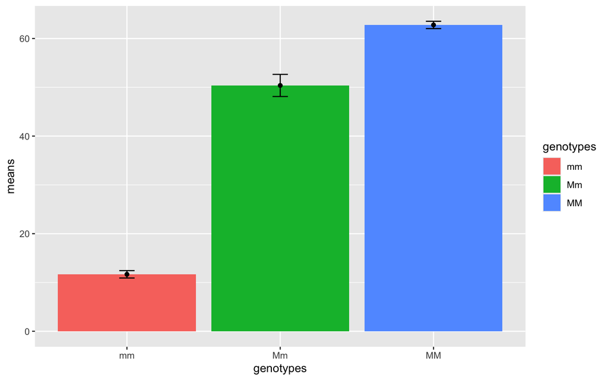

```r
ggplot(data = df) +
  geom_col(mapping = aes(x = genotypes,y=means,fill=genotypes)) +
  geom_errorbar(mapping = aes(x = genotypes,ymin=lower, ymax=upper), width=.1) +
  geom_point(mapping = aes(x = genotypes,y=means))
```

Either way, it is advised to also add the raw data:

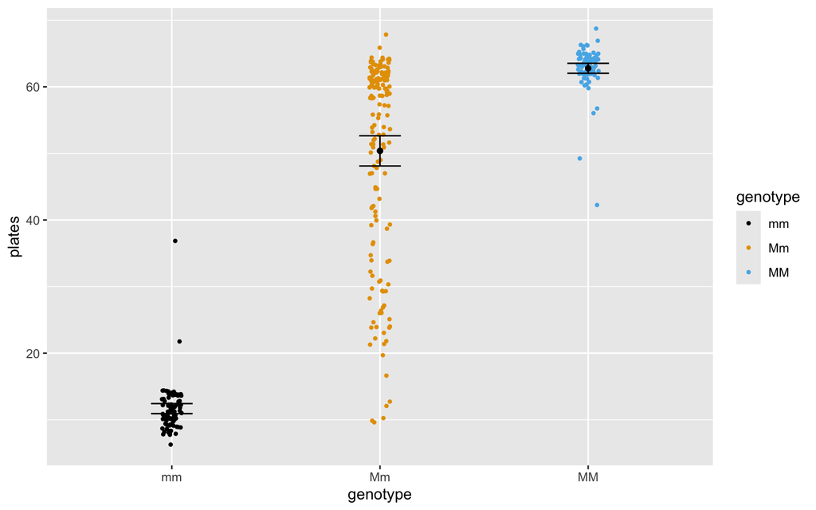

```r
ggplot(data = df)  +
  geom_jitter(data = stickleback,mapping = aes(x = genotype,y = plates,color=genotype),size=0.8,width=0.05)+
  geom_errorbar(mapping = aes(x = genotypes,ymin=lower, ymax=upper), width=.2) +
  geom_point(mapping = aes(x = genotypes,y=means))
```

## Exercise 14

We first choose values for $\mu$ and $\sigma$ (you can chose any values you want)

```r
mu = 10
sigma = 2
```

```r
x = seq(mu-4*sigma,mu+4*sigma,by=0.1)
```

Now we compute the corresponding $y$ values for our plot using the function dnorm:

```r
y = dnorm(x, mean = mu, sd = sigma)
```

I now do the same thing for the standard normal distribution:

```r
mu.std = 0
sigma.std = 1
x.std = seq(mu.std-4*sigma.std,mu.std+4*sigma.std,by=0.1)
y.std = dnorm(x.std, mean = 0, sd = 1)
```

And finally we plot both density functions next to each other:

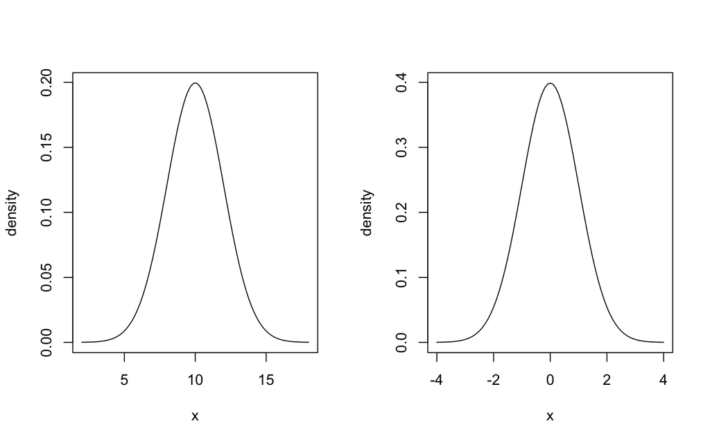

```r
par(mfrow = c(1,2))
plot(x,y,type="l",xlab="x",ylab="density")
plot(x.std,y.std,type="l",xlab="x",ylab="density")
```

We see that both curves look exactly the same. The only difference is the scale of the x and y axes.

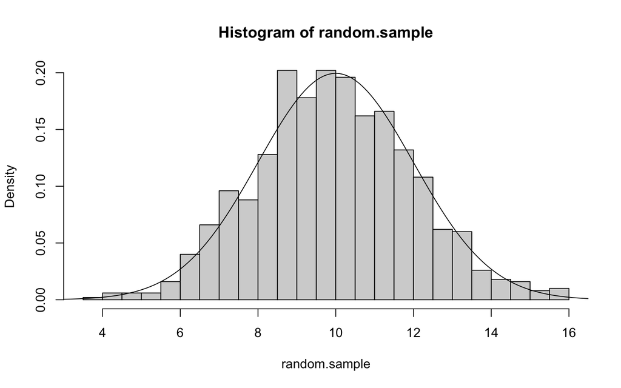

```r
random.sample = rnorm(1000,mu,sigma)
hist(random.sample,freq=F,ylim=c(0,0.2),breaks=30)
lines(x,y)
```

3. Calculate the 10 percent quantile of the distribution. Store the value in a variable $Q10$. Then calcualte the proportion of numbers in your random sample from (b) that are smaller or equal to $Q10$. What do you find?

```r
Q10 = qnorm(0.1,mean=mu,sd=sigma)
sum(random.sample<=Q10)/1000
```

```
## [1] 0.11
```

We find that approximately 10 percent of our random sample is smaller than $Q10$. This is exactly the definition of a quantile!

## Exercise 15

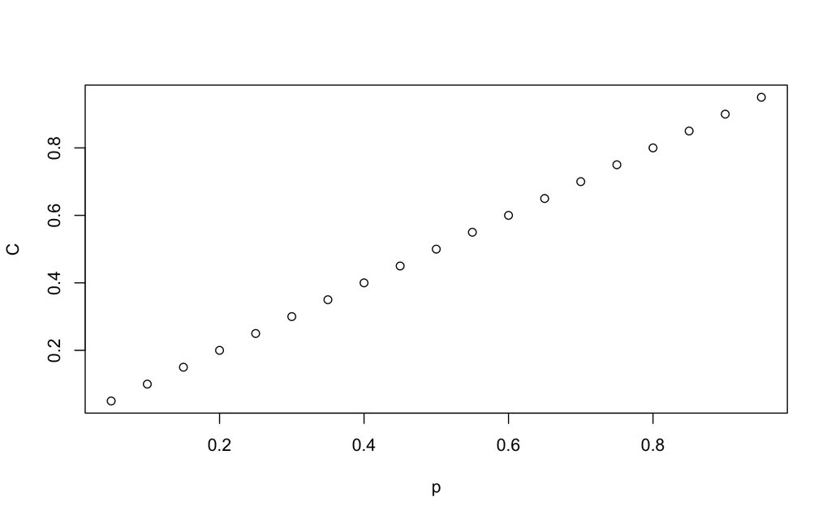

```r
  p = seq(0.05,0.95,by=0.05)
  Q = qnorm(p,mean=0,sd=1)
  C = pnorm(Q,mean=0,sd=1)
  plot(p,C)
```

We find that $p = C$. This means that the cumulative distribution function is the inverse of the quantile function.

The p-quantile $q_p$ is defined as the number such that
$$P(X < q_p) = p.$$
We define a quantile function $Q(p) = q_p$. The cumulative distribution function $F(x)$ gives us the value
$$F(x) = P(X<x)$$
Then $F(q_p) = P(X < q_p) = p$

and because

$$Q(p) = q_p$$
if follows

that

$$F(Q(p)) = F(q_p) = p$$
Here is a graphical representation of this relationship

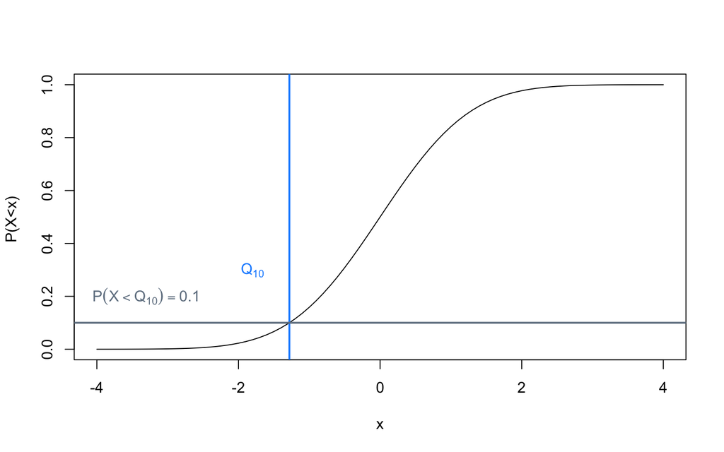

```r
cdf.std = pnorm(x.std,mean=0,sd=1)
plot(x.std,cdf.std,type="l",xlab="x",ylab = "P(X<x) ")
abline(v=qnorm(0.1,mean=0,sd=1),lwd=2,col="dodgerblue")
abline(h = 0.1,col="slategray",lwd=2)
text(-1.8,0.3,expression(Q[10]),col="dodgerblue")
text(-3.3,0.2,expression(P(X < Q[10])==0.1),col="slategray")
```

2. Indicate the smallest 5 percent of the distribution. In other words: Let $X$ be a normally distributed random variable. For which range $(-\infty,c_1]$ to we get $P(X \leq c_1) = 0.05$?

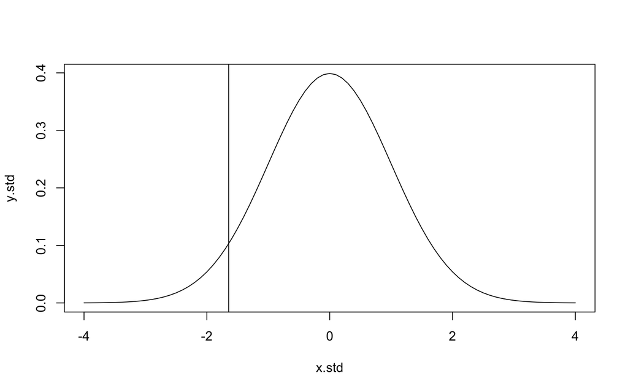

```r
mu.std = 0
sigma.std = 1
x.std = seq(mu.std-4*sigma.std,mu.std+4*sigma.std,by=0.1)
y.std = dnorm(x.std, mean = 0, sd = 1)
plot(x.std,y.std,type="l")
c1 = qnorm(0.05,0,1)
abline(v = c1)
```

3. Indicate the most extreme 5 percent of the distribution. In other words: For which range $(-\infty,c_2] \cup [c_2,\infty]$ to we get $P(X \leq c_2 \text{ or } X \ > c_2 ) = 0.05$? [Hint: you can use the quantile function of $R$ and the symmetry of the Normal distribution to simplify things]

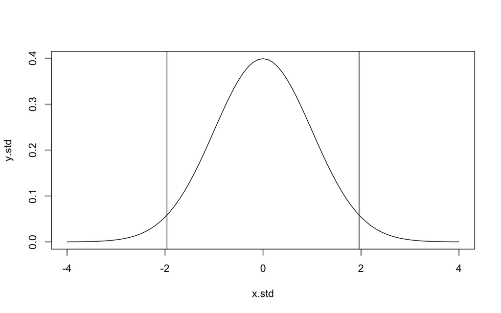

```r
mu.std = 0
sigma.std = 1
x.std = seq(mu.std-4*sigma.std,mu.std+4*sigma.std,by=0.1)
y.std = dnorm(x.std, mean = 0, sd = 1)
plot(x.std,y.std,type="l")
c2 = qnorm(c(0.025,0.975),0,1)
abline(v=c2)
```

We can add some simualted data if we want:

```r
set.seed(1984)
n = 1000
random.sample = rnorm(n,0,1)
sum(random.sample < c2[1] | random.sample > c2[2])/n
```

```
## [1] 0.052
```

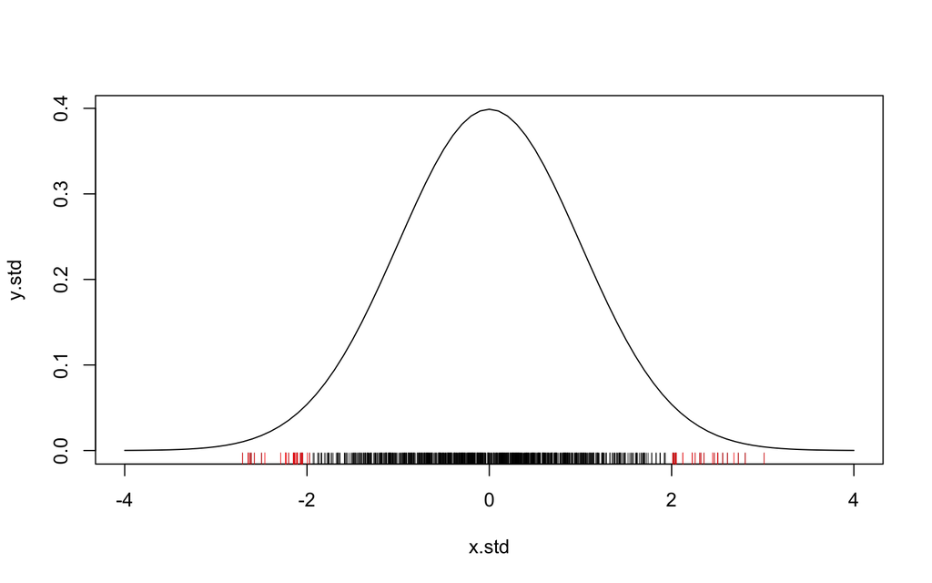

```r
plot(x.std,y.std,type="l")
rug(random.sample)
rug(random.sample[random.sample < c2[1] | random.sample > c2[2]],col="red")
```

We see that roughly 5 percent fall into the extreme tails of the distribution. this is sensible, because we have defined the extreme part here as the range $(-\infty,c_2] \cup [c_2,\infty]$, where $-c_2$ ($c_2$) is the 2.5 (97.5) percentile of the distribution.

# Week 7

## Exercise 16

Remember that pnorm(x) = P(Z < x) and that 1 - pnorm(x) = P(Z > x).

1. P(Z > 1.34)

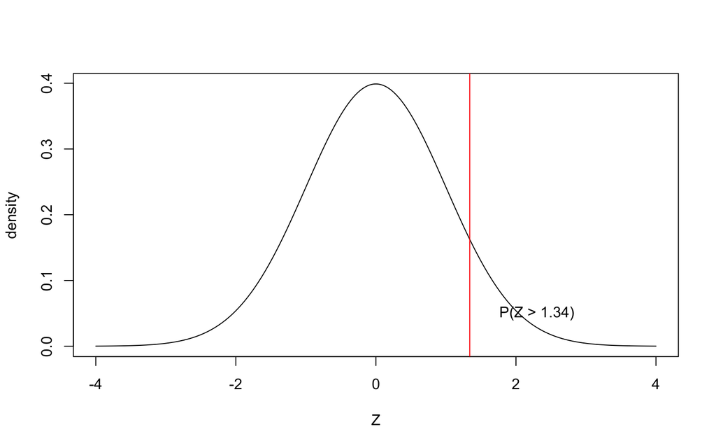

```r
x = seq(-4,4,by=0.01)
y = dnorm(x,0,1)
plot(x,y,type="l",xlab="Z",ylab="density")
abline(v = 1.34,col = "red")
text(2.3,0.05,"P(Z > 1.34)")
```

```r
prob = 1 - pnorm(1.34,0,1)
prob
```

```
## [1] 0.09012267
```

2. P(Z < 1.34)

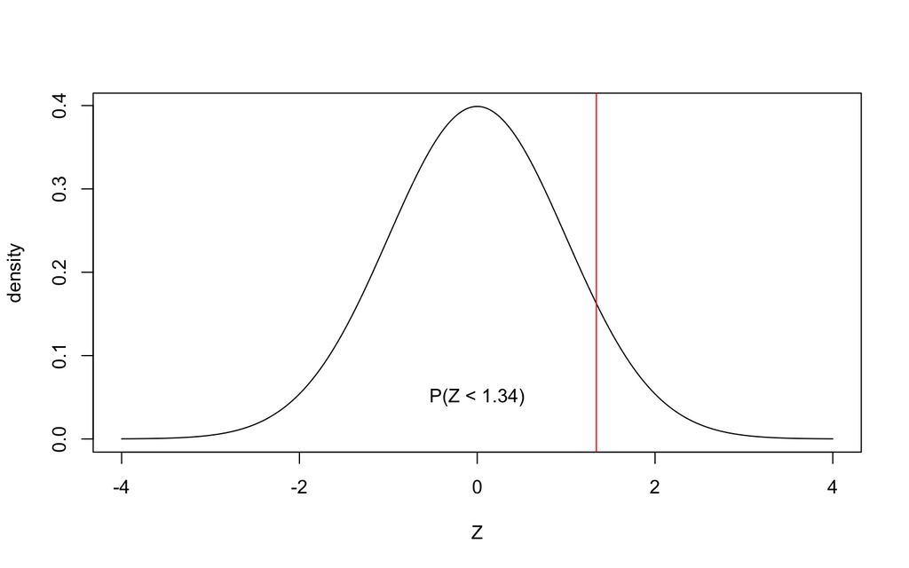

```r
plot(x,y,type="l",xlab="Z",ylab="density")
abline(v = 1.34,col = "red")
text(0,0.05,"P(Z < 1.34)")
```

```r
prob = pnorm(1.34,0,1)
prob
```

```
## [1] 0.9098773
```

3. P(Z < 2.15)

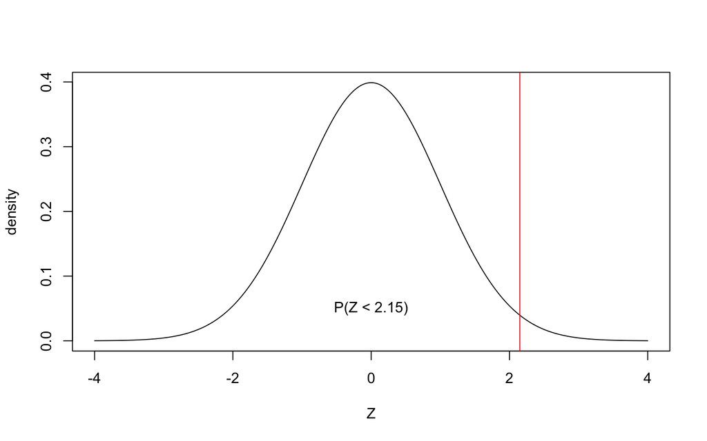

```r
plot(x,y,type="l",xlab="Z",ylab="density")
abline(v = 2.15,col = "red")
text(0,0.05,"P(Z < 2.15)")
```

```r
prob = pnorm(2.15,0,1)
prob
```

```
## [1] 0.9842224
```

4. P(Z < 1.2)

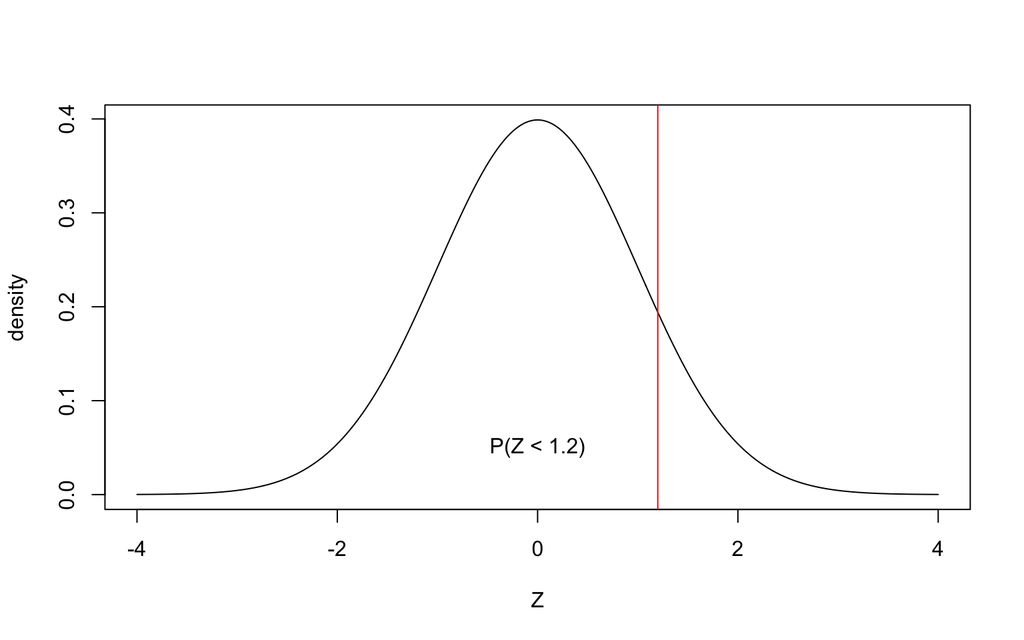

```r
plot(x,y,type="l",xlab="Z",ylab="density")
abline(v = 1.2,col = "red")
text(0,0.05,"P(Z < 1.2)")
```

```r
prob = pnorm(1.2,0,1)
prob
```

```
## [1] 0.8849303
```

5. P(0.52 < Z < 2.34)

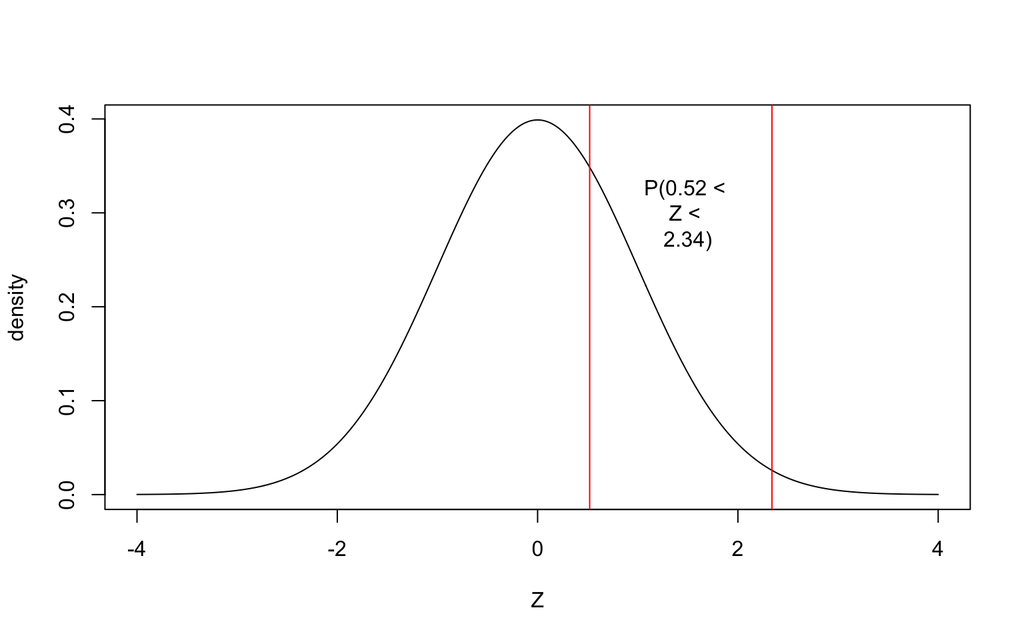

```r
plot(x,y,type="l",xlab="Z",ylab="density")
abline(v = 2.34,col = "red")
abline(v = 0.52,col = "red")

text(1.5,0.3,"P(0.52 <
Z <
2.34)")
```

```r
prob = pnorm(2.34,0,1) - pnorm(0.52,0,1)
prob
```

```
## [1] 0.2918899
```

6. P(-2.34 < Z < -0.52)

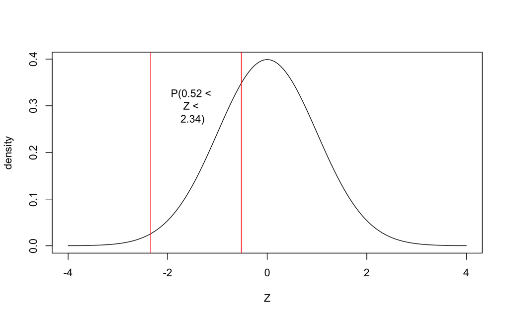

```r
plot(x,y,type="l",xlab="Z",ylab="density")
abline(v = -2.34,col = "red")
abline(v = -0.52,col = "red")

text(-1.5,0.3,"P(0.52 <
Z <
2.34)")
```

```r
prob = pnorm(-0.52,0,1) - pnorm(-2.34,0,1)
prob
```

```
## [1] 0.2918899
```

7. P(Z < -0.93)

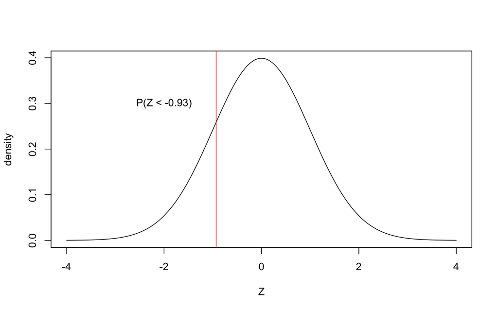

```r
plot(x,y,type="l",xlab="Z",ylab="density")
abline(v = -0.93,col = "red")

text(-2,0.3,"P(Z < -0.93)")
```

```r
prob = pnorm(-0.93,0,1)
prob
```

```
## [1] 0.1761855
```

8. P(-1.57 < Z < - 0.32)

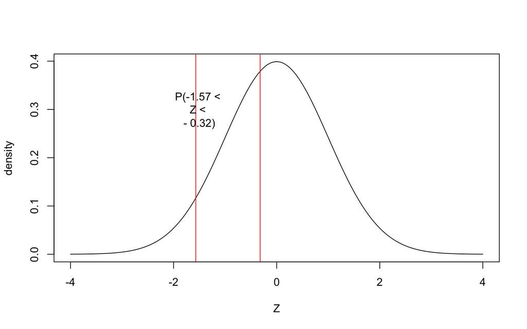

```r
plot(x,y,type="l",xlab="Z",ylab="density")
abline(v = -1.57,col = "red")
abline(v = - 0.32,col = "red")

text(-1.5,0.3,"P(-1.57 <
Z <
- 0.32)")
```

```r
prob = pnorm(-0.32,0,1) - pnorm(-1.57,0,1)
prob
```

```
## [1] 0.3162766
```